# exercise_part01

[Original Source](http://www.r-exercises.com/2017/04/10/forecasting-time-series-exploration-exercises-part-1/)

## Exercise 1

Read data from the file sales.csv

```r
df <- read.csv("sales.csv")
```

## Exercise 2

Transform the data into a time series object of the ts type (indicate that the data is monthly, and the starting period is Jan 1992). Print data.

```r
series <- ts(df, frequency = 12, start = c(1992,1))
print(series)
```

```
##        Jan   Feb   Mar   Apr   May   Jun   Jul   Aug   Sep   Oct   Nov
## 1992  6938  7524  8475  9401  9558  9182  9103 10513  9573 10254 11187
## 1993  7502  7524  8766  9867 10063  9635  9794 10628 10013 10346 11760
## 1994  7280  7902  9921  9869 10009  9893  9735 11157 10217 10730 12354
## 1995  7518  7961  9815 10168 10620 10301  9784 11264 10710 10439 12751
## 1996  7684  8991 10349 10570 11405 10554 10202 12134 10623 11250 12875
## 1997  8194  8835 10840 10131 11505 10654 10734 12461 10942 11635 13244
## 1998  8800  9499 10863 11825 12239 11451 11633 12971 11214 12384 13854
## 1999  9237 10171 12081 12386 13167 12280 12461 13734 12357 12948 14643
## 2000  9447 11170 12841 13124 13735 12953 12500 14610 13375 13369 15675
## 2001 10060 11450 13067 13362 13787 12935 12600 14818 12104 13218 15352
## 2002 10344 11730 13977 13195 14150 13210 12873 15113 12445 14006 15911
## 2003 10804 11662 13452 13691 14730 13496 13854 15522 13567 14601 16555
## 2004 11790 13344 14760 15058 15379 14237 14667 15588 14224 15570 17230
## 2005 12046 13878 15727 15708 15989 15559 15218 16697 14960 16509 18402
```

[output cut: 39 more lines]

## Exercise 3

Plot the time series. Ensure that the y axis starts from zero.

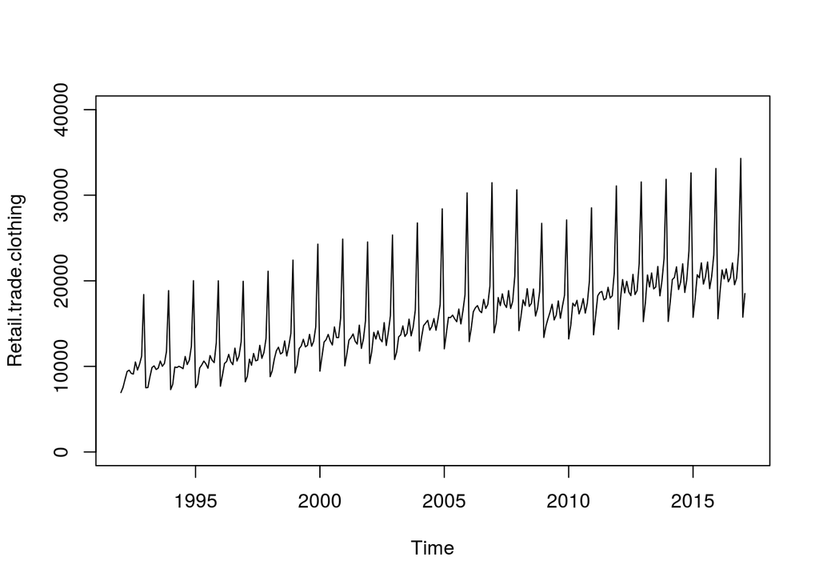

```r
plot(series, ylim=c(0,40000))
```

## Exercise 4

Use the gghistogram function from the **forecast** package to visually inspect the distribution of time series values. Add a kernel density estimate and a normal density function to the plot.

```r
require(forecast)
```

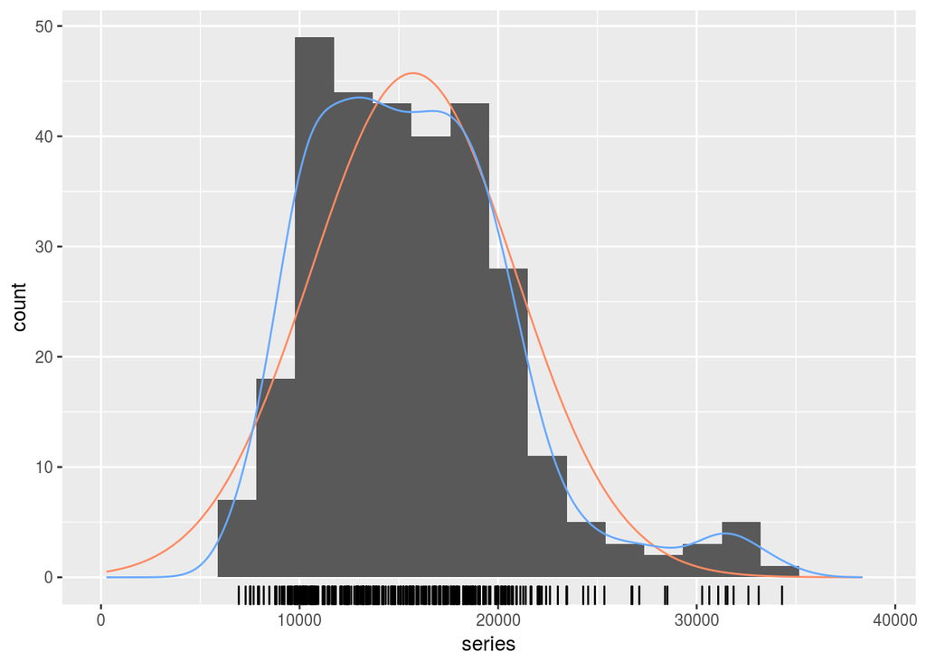

```r
gghistogram(series, add.normal = TRUE, add.kde = TRUE)
```

## Exercise 5

Use the **decompose** function to break the series into seasonal, trend, and irregular components (apply multiplicative decomposition). Plot the decomposed series.

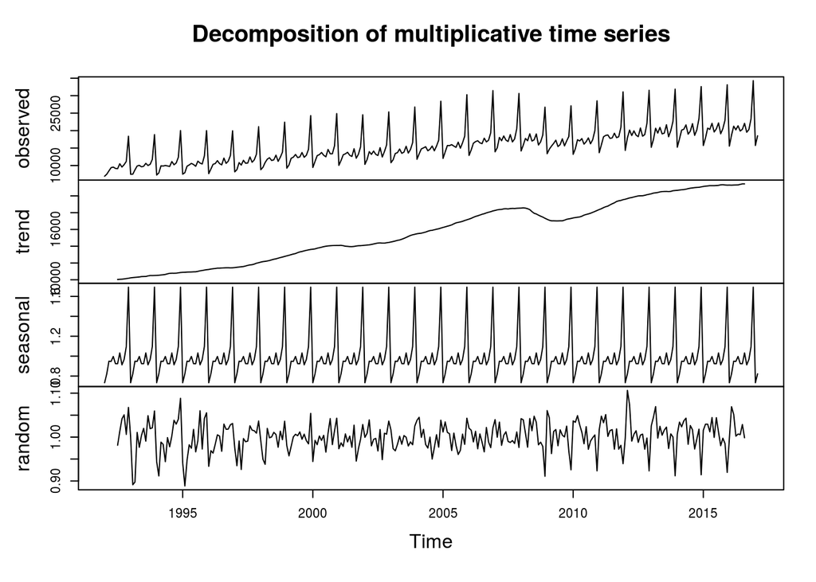

```r
series_decomposed <- decompose(series, type='multiplicative')
plot(series_decomposed)
```

## Exercise 6

Explore the structure of the decomposed object, and find seasonal coefficients (multiples). Identify the three months with the greatest coefficients, and the three months with the smallest coefficients. (Note that the coefficents are equal in different years).

```r
seasonal_coef <- data.frame(series_decomposed$figure)
seasonal_coef <- cbind(seasonal_coef, seq(1:12))
seasonal_coef[order(-seasonal_coef[,1]), ]
```

```
##    series_decomposed.figure seq(1:12)
## 12                1.6926382        12
## 11                1.0966024        11
## 8                 1.0321913         8
## 5                 0.9969609         5
## 10                0.9663104        10
## 3                 0.9495724         3
## 4                 0.9473508         4
## 6                 0.9249434         6
## 7                 0.9245634         7
## 9                 0.9130038         9
## 2                 0.8225737         2
## 1                 0.7332894         1
```

## Exercise 7

Check whether the times eries is trend-stationary (i.e. its mean and variance are constant with respect to a trend) using function **kpss.test** from the **tseries** package. (Note that the null hypothesis of the test is that the series is trend-stationary).

```r
require(tseries)
kpss.test(series)
```

```
##
##  KPSS Test for Level Stationarity
##
## data:  series
## KPSS Level = 5.551, Truncation lag parameter = 4, p-value = 0.01
```

## Exercise 8

Use the **diff** function to create a differenced time series (i.e. a series that includes differences between the values of the original series), and test it for trend stationarity.

```r
series_differenced <- diff(series)
kpss.test(series_differenced)
```

```
##
##  KPSS Test for Level Stationarity
##
## data:  series_differenced
## KPSS Level = 0.013917, Truncation lag parameter = 4, p-value = 0.1
```

## Exercise 9

Plot the differenced time series.

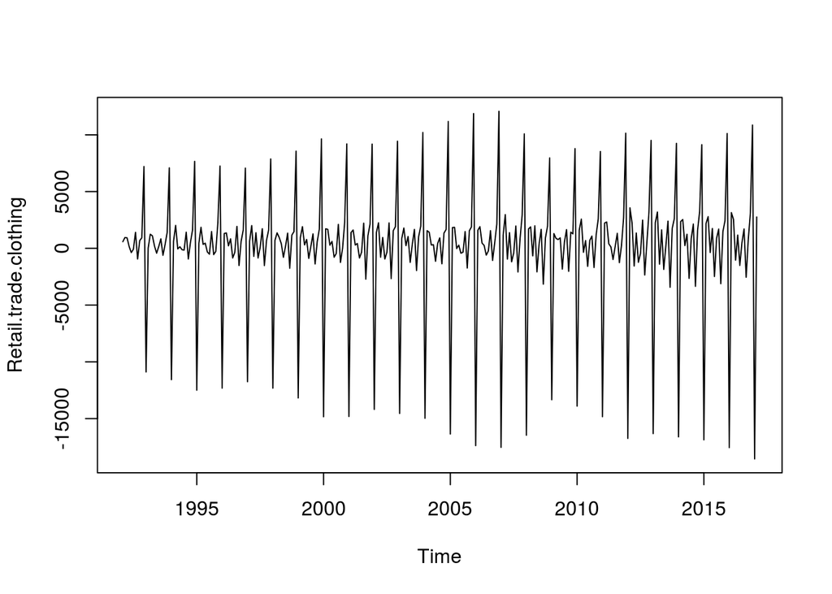

```r
plot(series_differenced)
```

## Exercise 10

Use the **Acf** and **Pacf** functions from the **forecast** package to explore autocorrelation of the differenced seires. Find at which lags correlation between lagged values is tstatistically significant at 5% level.

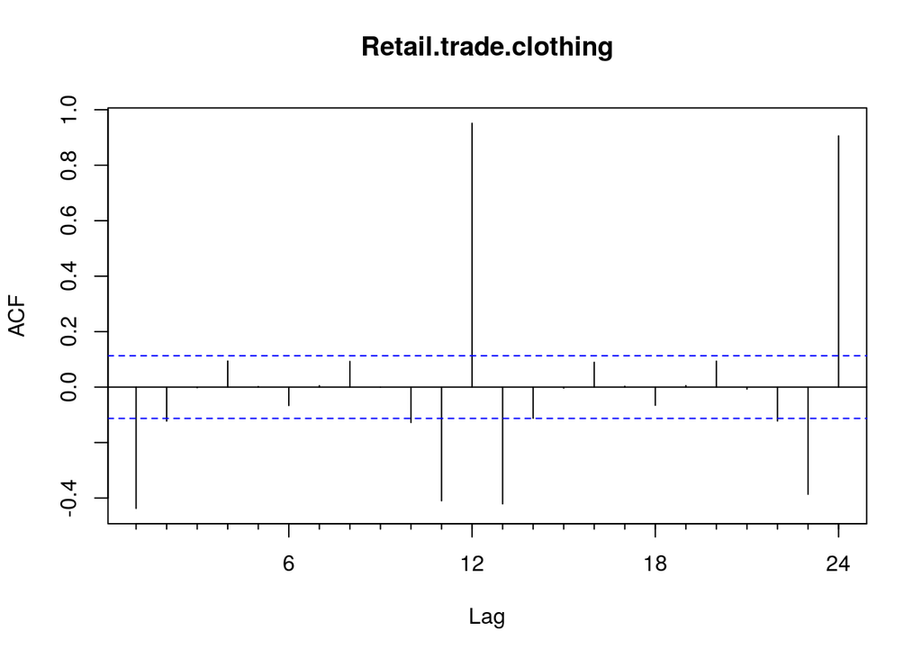

```r
require(forecast)
Acf(series_differenced)
```

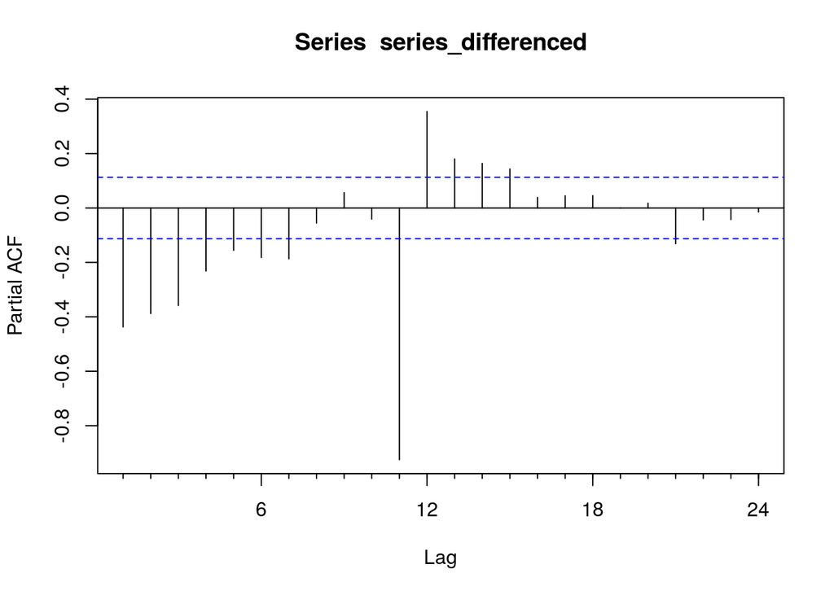

```r
Pacf(series_differenced)
```